# Extending the BYM2 Model for Disconnected Graphs

## Notebook setup

### Libraries and helper functions.

**Python**

```python
# import all libraries used in this notebook
import os
import numpy as np
import pandas as pd
import geopandas as gpd
import libpysal
import matplotlib
from splot.libpysal import plot_spatial_weights
%matplotlib inline

import warnings
warnings.filterwarnings('ignore')

from cmdstanpy import CmdStanModel, cmdstan_path, cmdstan_version

from utils_bym2 import get_scaling_factor, nbs_to_adjlist
from utils_nyc_map import *
from utils_dataviz import *
```

**R**

````markdown
```{r}
library(ggplot2)
library(igraph)
library(Matrix)
library(parallel)
library(sf)
library(spdep) |> suppressPackageStartupMessages()
library(tidyverse) |> suppressPackageStartupMessages()

library(cmdstanr)
library(posterior)
library(bayesplot)
library(loo)
cores = floor(parallel::detectCores() / 2)
source("utils_bym2.R")
source("utils_dataviz.R")
source("utils_nyc_map.R")
```
````

## The BYM2 Model for Disconnected Graphs: Freni-Sterrantino et al, 2018

### Graph Connectivity and Modeling Consequences

Neighbor graphs are used to model spatial relationships between areal regions (such as states, districts, or census tracts). Nodes in the graph correspond to regions and edges connect nodes whose corresponding regions share a common point or boundary line. Edges have no direction, i.e., an edge between $i$ and $j$ implies that $i$ is a neighbor of $j$ and $j$ is a neighbor of $i$.

*Components* represent groups of regions that are connected, either by a direct edge or a series of edges. The size of a component is the number of nodes in it. An island, or singleton, is a component of size 1, so we must distinguish between *connected components* of size 2 or greater and *singletons*.

If it is possible to find a path (series of edges) which connects any region in the graph to any other region, then the graph is *fully connected*, i.e., it consists of a single component. For example, at the state level, the neighbor graph of the 48 continental states of the U.S. is fully connected, but the graph of all 50 U.S. states and territories is *disconnected*; it consists of a connected component and several islands.

The ICAR model requires that the neighbor graph is fully connected for two reasons:

- The joint distribution is computed from the pairwise differences between a node and its neighbors; singleton nodes have no neighbors and are therefore undefined.
- Even if the graph doesn’t have any singleton nodes, when the graph has multiple connected components a sum-to-zero constraint on the entire vector fails to properly identify the model.

As the census tract map of New York City shows, when the metric used to compute spatial adjacency is a shared geographic point, the neighbor graph of NYC has several connected components and a few singleton nodes. In order to apply the BYM2 model to the full NYC dataset, it is necessary to either:

- Edit the neighbor graph to create a fully connected single component for NYC, as was done for the 2019 analysis of Morris et al.
- Extend the BYM2 model to account for disconnected components and singleton nodes - continue reading!

### Extending the BYM2 Model in Stan

We extend the BYM2 model to account for disconnected graphs and islands, following the recommendations from [A note on intrinsic Conditional Autoregressive models for disconnected graphs](https://arxiv.org/abs/1705.04854), Freni-Sterrantino et.al. 2018.

- Component nodes are given the BYM2 prior
- Singleton nodes (islands) are given a standard Normal prior
- Compute per-connected component scaling factor
- Impose a sum-to-zero constraint on each connected component

### Stan Implementation: `bym2_multicomp.stan`

The BYM2_multicomp model requires more additional data inputs: the number of components, their size, scaling factor, and the number of singleton nodes. Because neighbor graph uses the spatial dataframe row indices as the node labels, it is critical that the order of all data inputs matches the dataframe ordering, i.e., that for any row $i$ in the spatial dataframe, the $i^{th}$ element of the observed outcome `y` and design matrix `xs` match that row, and the node ids used in the `neighbors` edge pairs array. Data preprocessing consists of the following operations, in order:

- Create the neighbor graph from the spatial dataframe; add graph component labels to the dataframe.
- Create mapping from component labels to component sizes.
- Reorder the spatial dataframe so that it can be sliced by component, with singleton nodes last, by using the component id as the sort key and the component size, descending, as the sort order.
- Rebuild the neighbor graph so the its indices line up with the spatial dataframe row index.

We have written a series of helper functions in R and Python to do this which are in files `utils_nyc_map.py` and `utils_nyc_map.R`. For further details on editing spatial data structures see the notebook on spatial data: [Spatial Data Analysis in Python and R](https://github.com/mitzimorris/geomed_2024/blob/main/h2_spatial_data.qmd).

By reordering the spatial data frame by component membership, with singleton nodes at the end of the dataframe, we can easily implement both the component-wise sum to zero constraint and compute the spatial effects for connected nodes, using Stan’s [range indexing](https://mc-stan.org/docs/reference-manual/expressions.html#language-multi-indexing.section) expressions, which return slices of an array. See the Stan User’s Guide, section [slicing with range indexes](https://mc-stan.org/docs/stan-users-guide/multi-indexing.html#slicing-with-range-indexes) for details.

#### Changes to the `data` block

The model needs a few more pieces of information: the number of connected components, the size and scaling factor for each.

```stan
data {
  ...
  int<lower=0, upper=N> N_components;
  array[N_components] int<lower=1, upper=N> component_sizes;
  vector<lower=0>[N_components] scaling_factors;  // vector instead of a scalar

  // neighbor graph structure
  int<lower = 0> N_edges;  // number of neighbor pairs
  array[2, N_edges] int<lower = 1, upper = (sum(component_sizes))> neighbors;  // was upper = N
}
```

#### Changes to the `transformed data` block

First we check that the input data is consistent.

```stan
transformed data {
  ...
  int N_connected = sum(component_sizes);
  int N_singletons = N - N_connected;
  if (N_singletons < 0) {
    reject("Inconsistent inputs: sum(component_sizes) > N");
  }
  ...
```

Then we use component sizes to compute the begin and end indices needed to slice the spatial vector `phi`. At the same time, we create vector `taus`, the per-region scaling factor.

```stan
  for (n in 1:N_components) {
    taus[idx: idx + component_sizes[n] - 1]
      = rep_array(scaling_factors[n], idx, component_sizes[n]);
    component_idxs[n, 1] = idx;
    component_idxs[n, 2] = idx + component_sizes[n] - 1;
    idx += component_sizes[n];
  }
```

#### Changes to the `parameters` block: constraining transforms

In the BYM2 model for a fully connected graph the sum-to-zero constraint on `phi` is implemented directly by declaring `phi` to be a `sum_to_zero_vector`, which is a [constrained parameter type](https://mc-stan.org/docs/reference-manual/transforms.html#variable-transforms.chapter). The declaration:

```stan
  sum_to_zero_vector[N] phi;  // spatial effects
```

creates a *constrained* variable of length $N$, with a corresponding unconstrained variable of length $N-1$.

For the BYM2_multicomp model, we need to do declare the *unconstrained* parameter vector `phi_raw` and the constraining transform, which is applied component-wise, to slices of `phi_raw`. The number of connected components is $N\_components$, therefore the length of vector `phi_raw` is $N - N\_components$.

```stan
  vector[N - N_components] phi_raw;  // spatial effects
```

In the `transformed parameters` block, we apply the constraining transform.

```stan
  vector[N_connected] phi = zero_sum_components_lp(phi_raw, component_idxs, component_sizes);
```

#### Adding a `functions` block for the constraining transform

This transform is implemented by two functions in the `functions` block.

- `zero_sum_constrain_lp`: the constraining transform, following the `zero_sum_vector` implementation.

```stan
  /**
   * Constrain sum-to-zero vector
   *
   * @param y unconstrained zero-sum parameters
   * @return vector z, the vector whose slices sum to zero
   */
  vector zero_sum_constrain_lp(vector y) {
    int N = num_elements(y);
    vector[N + 1] z = zeros_vector(N + 1);
    real sum_w = 0;
    for (ii in 1:N) {
      int i = N - ii + 1;
      real n = i;
      real w = y[i] * inv_sqrt(n * (n + 1));
      sum_w += w;
      z[i] += sum_w;
      z[i + 1] -= w * n;
    }
    return z;
  }
```

- `zero_sum_components_lp`: slices vector `phi` by component, applies constraining transform to each.

```stan
  /**
   * Component-wise constrain sum-to-zero vectors
   *
   * @param phi unconstrained vector of zero-sum slices
   * @param idxs component start and end indices
   * @param sizes component sizes
   * @return vector phi_ozs, the vector whose slices sum to zero
   */
  vector zero_sum_components_lp(vector phi,
                                array[ , ] int idxs,
                                array[] int sizes) {
    vector[sum(sizes)] phi_ozs;
    int idx_phi = 1;
    int idx_ozs = 1;
    for (i in 1:size(sizes)) {
      phi_ozs[idx_ozs : idx_ozs + sizes[i] - 1] =
        zero_sum_constrain_lp(segment(phi, idx_phi, sizes[i] - 1));
      idx_phi += sizes[i] - 1;
      idx_ozs += sizes[i];
    }
    return phi_ozs;
  }
```

### Putting it all together: `bym2_multicomp.stan`

**Python**

```python
bym2_multicomp_file = os.path.join('..', 'stan', 'bym2_multicomp.stan')

with open(bym2_multicomp_file, 'r') as file:
    contents = file.read()
    print(contents)
```

```
functions {
  /**
   * Component-wise constrain sum-to-zero vectors
   *
   * @param phi unconstrained vector of zero-sum slices
   * @param idxs component start and end indices
   * @param sizes component sizes
   * @return vector phi_ozs, the vector whose slices sum to zero
   */
  vector zero_sum_components_lp(vector phi, array[ , ] int idxs, array[] int sizes) {
    vector[sum(sizes)] phi_ozs;
    int idx_phi = 1;
    int idx_ozs = 1;
    for (i in 1:size(sizes)) {
      int n = sizes[i];
      phi_ozs[idx_ozs : idx_ozs + n - 1] =
        zero_sum_constrain_lp(segment(phi, idx_phi, n - 1));
      idx_phi += n - 1;
      idx_ozs += n;
    }
    return phi_ozs;
  }

  /**
   * Constrain sum-to-zero vector
   *
   * @param y unconstrained zero-sum parameters
   * @return vector z, the vector whose slices sum to zero
   */
  vector zero_sum_constrain_lp(vector y) {
    int N = num_elements(y);
    vector[N + 1] z = zeros_vector(N + 1);
    real sum_w = 0;
    for (ii in 1:N) {
      int i = N - ii + 1;
      real n = i;
      real w = y[i] * inv_sqrt(n * (n + 1));
      sum_w += w;
      z[i] += sum_w;
      z[i + 1] -= w * n;
```

[output cut: 73 more lines]

```
  theta ~ std_normal();
  singletons_re ~ std_normal();
  sigma ~ std_normal();
  rho ~ beta(0.5, 0.5);
  target += -0.5 * dot_self(phi[neighbors[1]] - phi[neighbors[2]]);  // ICAR
}

generated quantities {
  real beta_intercept = beta0 - dot_product(means_xs, betas);  // adjust intercept
  array[N] int y_rep;
  {
    vector[N] eta = log_E + beta0 + xs_centered * betas + gamma * sigma;
    y_rep = max(eta) < 26 ? poisson_log_rng(eta) : rep_array(-1, N);
  }
}
```

**R**

````markdown
```{r}
bym2_multicomp_file = file.path('..', 'stan', 'bym2_multicomp.stan')
cat(readLines(bym2_multicomp_file), sep="\n")
```
````

## Fitting the BYM2_multicomp Model to the NYC Dataset

### Data Assembly

We need to assemble a dictionary or list for all variables declared in the model’s data block. These are:

```stan
data {
  int<lower=0> N;
  array[N] int<lower=0> y; // count outcomes
  vector<lower=0>[N] E; // exposure
  int<lower=1> K; // num covariates
  matrix[N, K] xs; // design matrix

  int<lower=0, upper=N> N_components;
  array[N_components] int<lower=1, upper=N> component_sizes;
  vector<lower=0>[N_components] scaling_factors;
  int<lower=0, upper=N> N_singletons;

  // neighbor graph structure
  int<lower = 0> N_edges;  // number of neighbor pairs
  array[2, N_edges] int<lower = 1, upper = (N - N_singletons)> neighbors;  // columnwise adjacent
}
```

#### Load the NYC dataset

**Python**

```python
nyc_geodata = gpd.read_file(os.path.join('..', 'data', 'nyc_study.geojson'))
nyc_geodata.columns
```

```
Index(['CTLabel', 'BoroCode', 'BoroName', 'CT2010', 'BoroCT2010', 'CDEligibil',
       'NTACode', 'NTAName', 'PUMA', 'Shape_Leng', 'Shape_Area', 'BoroFips',
       'ct2010full', 'kids_per_sq_mi', 'count', 'kid_pop', 'pct_pubtransit',
       'med_hh_inc', 'traffic', 'frag_index', 'geometry'],
      dtype='object')
```

**R**

````markdown
```{r}
nyc_geodata = st_read(file.path('..', 'data', 'nyc_study.geojson'))
names(nyc_geodata)
```
````

#### NYC neighbor graph cleanup

Create the neighbors graph and plot the map. This shows a set of spurious connections between Manhattan and Brooklyn and Queens, (likely due to bridges and tunnels).

**Python**

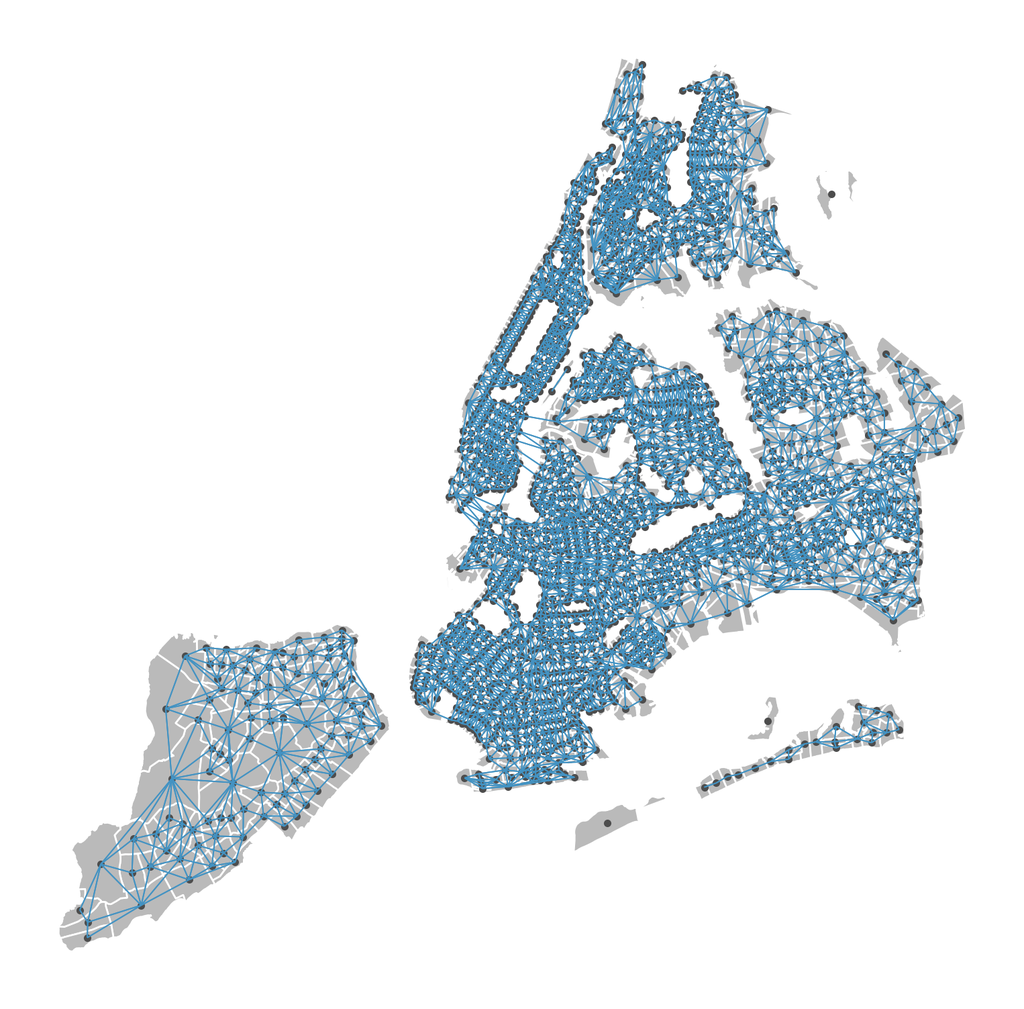

```python
nyc_nbs_all = libpysal.weights.Queen.from_dataframe(nyc_geodata, geom_col='geometry')
plot_spatial_weights(nyc_nbs_all, nyc_geodata)
```

**R**

````markdown
```{r}
nyc_nbs_all = poly2nb(nyc_geodata)
nyc_coords = st_coordinates(st_centroid(nyc_geodata['geometry']))
plot(st_geometry(nyc_geodata), col='skyblue')
plot(nyc_nbs_all, coords=nyc_coords, add=TRUE, pch=20, cex=0.6)
```
````

In order to ensure that the spatial graph accurately reflects real‐world connectivity, we have written a helper function to disconnect Manhattan from Queens and Brooklyn. However, as Queens and Brooklyn are in fact the same land mass (Long Island), we don’t try to disconnect Brooklyn from Queens.

To check that the neighbor graph is correct, we replot it.

**Python**

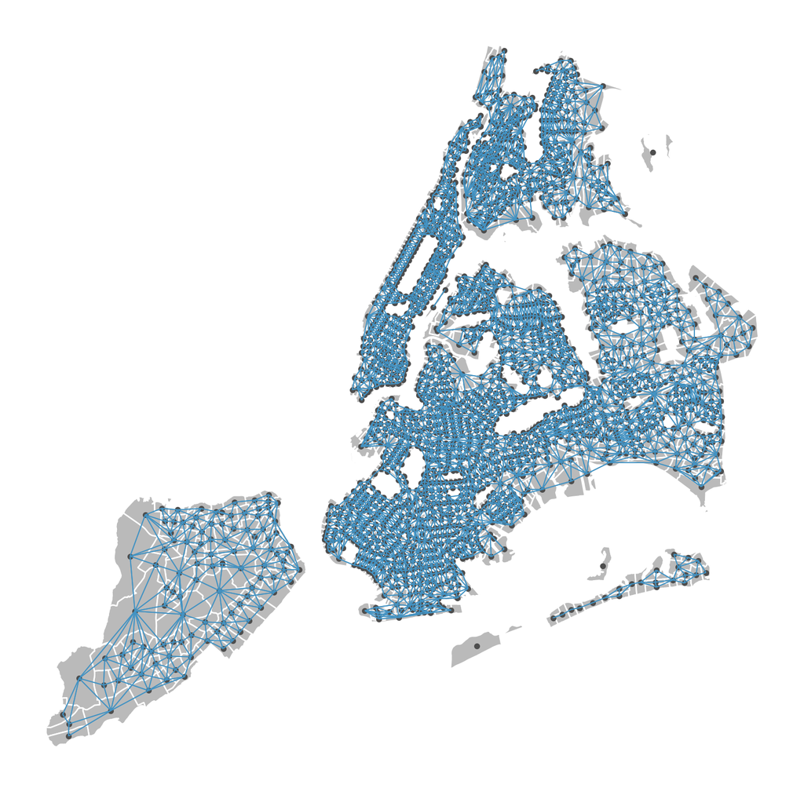

```python
nyc_nbs = nyc_cleanup(nyc_nbs_all, nyc_geodata)
plot_spatial_weights(nyc_nbs, nyc_geodata)
```

**R**

````markdown
```{r}
nyc_nbs = nyc_cleanup(nyc_nbs_all, nyc_geodata)
plot(st_geometry(nyc_geodata), col='skyblue')
plot(nyc_nbs, coords=nyc_coords, add=TRUE, pch=20, cex=0.6)
```
````

#### Arranging the dataset by component

To reorder the spatial dataframe so that it can be sliced by component, with singleton nodes last, and rebuild the corresponding neighbor graph, we have written function `nyc_sort_by_comp_size`, which takes into account the necessity of correcting for problems in the NYC geodata. A general version for maps where the spatial graph lines up with real-world connectivity, this function could be simplified.

**Python**

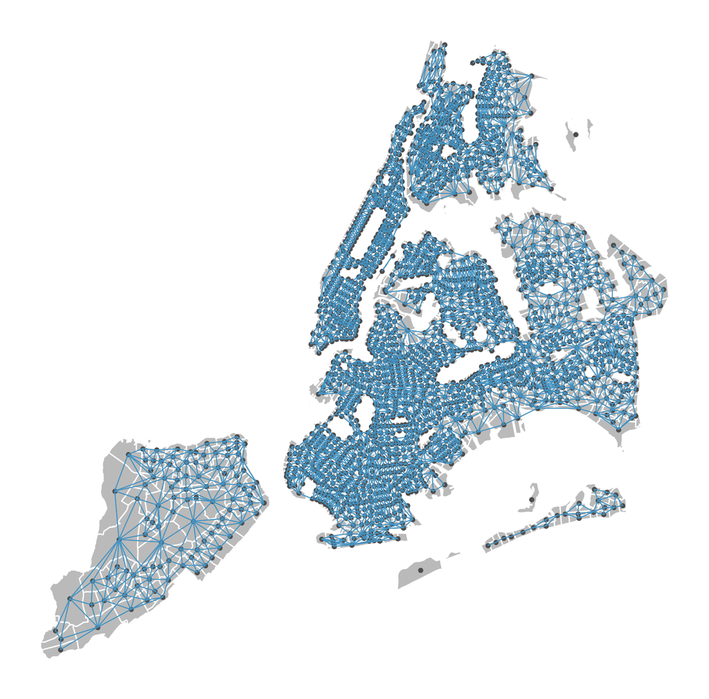

```python
(nyc_nbs, nyc_gdf, sizes) = nyc_sort_by_comp_size(nyc_geodata)
plot_spatial_weights(nyc_nbs, nyc_gdf)
```

```python
nyc_gdf[['NTAName', 'comp_id', 'comp_size']].head(4)
```

|  | NTAName | comp_id | comp_size |
| --- | --- | --- | --- |
| 0 | East New York | 0 | 1360 |
| 1 | Flatbush | 0 | 1360 |
| 2 | Erasmus | 0 | 1360 |
| 3 | Flatbush | 0 | 1360 |

```python
nyc_gdf[['NTAName', 'comp_id', 'comp_size']].tail(4)
```

|  | NTAName | comp_id | comp_size |
| --- | --- | --- | --- |
| 2091 | Lenox Hill-Roosevelt Island | 5 | 2 |
| 2092 | Breezy Point-Belle Harbor-Rockaway Park-Broad ... | 6 | 1 |
| 2093 | Breezy Point-Belle Harbor-Rockaway Park-Broad ... | 7 | 1 |
| 2094 | Pelham Bay-Country Club-City Island | 8 | 1 |

**R**

````markdown
```{r}
nyc_components = nyc_sort_by_comp_size(nyc_geodata)
nyc_nbs = nyc_components$nb
nyc_gdf = nyc_components$sf_sorted
sizes = nyc_components$component_sizes

### pad for plotting
nyc_nbs_padded = nyc_nbs
nyc_nbs_padded[2093] = 0L
nyc_nbs_padded[2094] = 0L
nyc_nbs_padded[2095] = 0L
nyc_coords = st_coordinates(st_centroid(nyc_gdf['geometry']))
plot(st_geometry(nyc_gdf), col='skyblue')
plot(nyc_nbs_padded, coords=nyc_coords, add=TRUE, pch=20, cex=0.6)
```
````

#### Get edgeset

**Python**

```python
nyc_nbs_adj = nbs_to_adjlist(nyc_nbs)
nyc_nbs_adj
```

```
array([[   1,    1,    1, ..., 2086, 2087, 2091],
       [ 576,  587,  588, ..., 2088, 2088, 2092]])
```

**R**

````markdown
```{r}
nyc_nbs_adj = nbs_to_adjlist(nyc_nbs)
nyc_nbs_adj[1:2, 1:10]
```
````

#### Get regression inputs

**Python**

```python
N = nyc_gdf.shape[0]
y = nyc_gdf['count'].astype('int')
E = nyc_gdf['kid_pop'].astype('int')
K = 4

design_vars = np.array(['pct_pubtransit','med_hh_inc', 'traffic', 'frag_index'])
design_mat = nyc_gdf[design_vars].to_numpy()
design_mat[:, 1] = np.log(design_mat[:, 1])
design_mat[:, 2] = np.log(design_mat[:, 2])
pd.DataFrame(data=design_mat).describe()
```

|  | 0 | 1 | 2 | 3 |
| --- | --- | --- | --- | --- |
| count | 2095.000000 | 2095.000000 | 2095.000000 | 2.095000e+03 |
| mean | 0.697427 | 10.862932 | 10.053935 | 5.250597e-07 |
| std | 0.191031 | 0.485851 | 0.913035 | 2.677234e+00 |
| min | 0.097700 | 9.140669 | 6.736967 | -6.728700e+00 |
| 25% | 0.561000 | 10.561629 | 9.420682 | -1.818600e+00 |
| 50% | 0.739100 | 10.894552 | 9.861519 | -1.085000e-01 |
| 75% | 0.854050 | 11.197235 | 10.524091 | 1.436550e+00 |
| max | 1.000000 | 12.355639 | 12.529879 | 1.867200e+01 |

**R**

````markdown
```{r}
N = nrow(nyc_gdf)
y = as.integer(nyc_gdf$count)
E = as.integer(nyc_gdf$kid_pop)
K = 4

design_mat <- as.data.frame(nyc_gdf) %>%
  select(pct_pubtransit, med_hh_inc, traffic, frag_index) %>%
  mutate(med_hh_inc = log(med_hh_inc),
         traffic = log(traffic))
summary(design_mat)
```
````

#### Compute number of components, sizes, and number of singleton nodes

**Python**

```python
component_sizes = [x for x in sizes if x > 1]
N_components = len(component_sizes)
print("N_components ", N_components, " component_sizes ", component_sizes)
print("N connected ", np.sum(component_sizes))
```

```
N_components  6  component_sizes  [1360, 329, 271, 108, 22, 2]
N connected  2092
```

**R**

````markdown
```{r}
component_sizes <- sizes[sizes > 1]
N_components <- length(component_sizes)
cat("N_components:", N_components, "component_sizes:", component_sizes, "\n")
cat("N connected:", sum(component_sizes), "\n")
```
````

#### Compute per-component scaling factors

**Python**

```python
scaling_factors = np.ones(N_components)
for i in range(N_components):
    comp_gdf = nyc_gdf[nyc_gdf['comp_id'] == i].reset_index(drop=True)
    comp_nbs = libpysal.weights.Queen.from_dataframe(comp_gdf, geom_col='geometry')
    component_w = libpysal.weights.W(comp_nbs.neighbors, comp_nbs.weights)
    scaling_factors[i] = get_scaling_factor(component_w)

print(scaling_factors)
```

```
[0.70664959 0.56716043 0.79757677 0.3574707  1.19040914 0.25      ]
```

**R**

````markdown
```{r}
scaling_factors <- rep(1, N_components)

for (i in seq_len(N_components)) {
    comp_gdf <- nyc_gdf[nyc_gdf$comp_id == i, ]
    comp_nbs <- poly2nb(comp_gdf)
    scaling_factors[i] <- get_scaling_factor(comp_nbs)
}

print(scaling_factors)
```
````

#### Assemble the input data into a Python dict, R list

**Python**

```python
# assemble nyc_data_dict
bym2_data = {
    'N':N,
    'y':y,
    'E':E,
    'K':K,
    'xs':design_mat,
    'N_components':N_components,
    'component_sizes': component_sizes,
    'N_edges':nyc_nbs_adj.shape[1],
    'neighbors':nyc_nbs_adj,
    'scaling_factors': scaling_factors
}
```

**R**

````markdown
```{r}
bym2_data <- list(
  N = N,
  y = y,
  E = E,
  K = 4,
  xs = as.matrix(design_mat),
  N_components = N_components,
  component_sizes = component_sizes,
  N_edges = ncol(nyc_nbs_adj),
  neighbors = nyc_nbs_adj,
  scaling_factors = scaling_factors
)
```
````

## Prior predictive checks

Check that variance of scaled phi is approx $1$.

**Python**

```python
bym2_multicomp_gamma_ppc_file = os.path.join('..', 'stan', 'bym2_multicomp_gamma_ppc.stan')
with open(bym2_multicomp_gamma_ppc_file, 'r') as file:
    contents = file.read()
    print(contents)
bym2_multicomp_gamma_ppc_mod = CmdStanModel(stan_file=bym2_multicomp_gamma_ppc_file)
```

```
functions {
  /**
   * Component-wise constrain sum-to-zero vectors
   *
   * @param phi unconstrained vector of zero-sum slices
   * @param idxs component start and end indices
   * @param sizes component sizes
   * @return vector phi_ozs, the vector whose slices sum to zero
   */
  vector zero_sum_components_lp(vector phi, array[ , ] int idxs, array[] int sizes) {
    vector[sum(sizes)] phi_ozs;
    int idx_phi = 1;
    int idx_ozs = 1;
    for (i in 1:size(sizes)) {
      int n = sizes[i];
      phi_ozs[idx_ozs : idx_ozs + n - 1] =
        zero_sum_constrain_lp(segment(phi, idx_phi, n - 1));
      idx_phi += n - 1;
      idx_ozs += n;
    }
    return phi_ozs;
  }

  /**
   * Constrain sum-to-zero vector
   *
   * @param y unconstrained zero-sum parameters
   * @return vector z, the vector whose slices sum to zero
   */
  vector zero_sum_constrain_lp(vector y) {
    int N = num_elements(y);
    vector[N + 1] z = zeros_vector(N + 1);
    real sum_w = 0;
    for (ii in 1:N) {
      int i = N - ii + 1;
      real n = i;
      real w = y[i] * inv_sqrt(n * (n + 1));
      sum_w += w;
      z[i] += sum_w;
      z[i + 1] -= w * n;
```

[output cut: 47 more lines]

```

transformed parameters {
  vector[N_connected] phi = zero_sum_components_lp(phi_raw, component_idxs, component_sizes);
  vector[N] gamma;  // BYM2, per Freni-Sterrantino
  gamma[1 : N_connected] = sqrt(1 - rho) * theta + sqrt(rho * inv(taus)) .* phi;
  gamma[N_connected + 1 : N] = singletons_re;
}

model {
  rho ~ beta(0.5, 0.5);
  target += -0.5 * dot_self(phi[neighbors[1]] - phi[neighbors[2]]);  // ICAR
  theta ~ std_normal();
  sigma ~ std_normal();
  singletons_re ~ std_normal();
}
```

**R**

````markdown
```{r}
bym2_multicomp_gamma_ppc_file = file.path('..', 'stan', 'bym2_multicomp_gamma_ppc.stan')
cat(readLines(bym2_multicomp_gamma_ppc_file), sep="\n")
bym2_multicomp_gamma_ppc_mod = cmdstan_model(stan_file=bym2_multicomp_gamma_ppc_file)
```
````

**Python**

```python
bym2_multicomp_gamma_ppc_fit = bym2_multicomp_gamma_ppc_mod.sample(data = bym2_data)
```

```
09:42:13 - cmdstanpy - INFO - CmdStan start processing
```

```
09:42:49 - cmdstanpy - INFO - CmdStan done processing.
```

```python
# broadcast per-component scaling factor to vector taus
# (done in model's `transformed data block)
N_connected = np.sum(component_sizes)
taus = np.zeros(N_connected)
idx = 0
for n, size in enumerate(component_sizes):
    start_idx = idx
    end_idx = idx + size
    taus[start_idx:end_idx] = scaling_factors[n]
    idx = end_idx

phi = bym2_multicomp_gamma_ppc_fit.stan_variable('phi')
phi_var_by_region = np.var((np.sqrt(1/taus) * phi), axis=0)
print('mean variance of phi scaled', np.mean(phi_var_by_region))

theta = bym2_multicomp_gamma_ppc_fit.stan_variable('theta')
print('mean variance of theta', np.mean(np.var(theta, axis=0)))
```

```
mean variance of phi scaled 1.1019274561102539
mean variance of theta 1.0004199869460695
```

**R**

````markdown
```{r}
bym2_multicomp_gamma_ppc_fit = bym2_multicomp_gamma_ppc_mod$sample(data=bym2_data,
                 parallel_chains=cores, refresh=0)
```
````

````markdown
```{r}
# broadcast per-component scaling factor to vector taus
# (done in model's `transformed data block)
N_connected <- sum(component_sizes)
taus <- numeric(N_connected)
idx <- 1
for (n in seq_along(component_sizes)) {
  start_idx <- idx
  end_idx <- component_sizes[n] + idx - 1
  taus[start_idx:end_idx] <- rep(scaling_factors[n], component_sizes[n])
  idx <- end_idx + 1
}

phi <- as_draws_matrix(bym2_multicomp_gamma_ppc_fit$draws("phi"))
phi_scaled <- sweep(phi, 2, sqrt(1 / taus), "*")
phi_var_by_region <- apply(phi, 2, var)
print(paste("mean variance of phi scaled:", mean(phi_var_by_region)))

theta <- as_draws_matrix(bym2_multicomp_gamma_ppc_fit$draws("theta"))
theta_var_by_region <- apply(theta, 2, var)
print(paste("mean variance of theta:", mean(theta_var_by_region)))
```
````

#### Check `rho`

The fitted model also provides an estimate of `rho`, which has prior

```stan
rho ~ beta(0.5, 0.5);
```

As expected, before seeing any data, the value of `rho` matches the prior.

**Python**

```python
rho = bym2_multicomp_gamma_ppc_fit.stan_variable('rho')
print('mean rho', np.mean(rho))
```

```
mean rho 0.5068464161872795
```

**R**

````markdown
```{r}
rho <- as_draws_array(bym2_multicomp_gamma_ppc_fit$draws("rho"))
mean(rho)
```
````

## Fit model to data

**Python**

```python
bym2_multicomp_mod = CmdStanModel(stan_file=bym2_multicomp_file)
```

**R**

````markdown
```{r}
bym2_multicomp_mod = cmdstan_model(stan_file=bym2_multicomp_file)
```
````

**Python**

```python
bym2_multicomp_fit = bym2_multicomp_mod.sample(data=bym2_data, iter_warmup=3000, iter_sampling=2000)

bym2_multicomp_summary = bym2_multicomp_fit.summary()
bym2_multicomp_summary.round(2).loc[
  ['beta_intercept', 'beta0', 'betas[1]', 'betas[2]', 'betas[3]', 'betas[4]', 'sigma', 'rho']]
```

```
09:42:53 - cmdstanpy - INFO - CmdStan start processing
```

```
09:44:25 - cmdstanpy - INFO - CmdStan done processing.
```

|  | Mean | MCSE | StdDev | MAD | 5% | 50% | 95% | ESS_bulk | ESS_tail | R_hat |
| --- | --- | --- | --- | --- | --- | --- | --- | --- | --- | --- |
| beta_intercept | -5.77 | 0.01 | 0.57 | 0.57 | -6.70 | -5.78 | -4.82 | 1508.50 | 2760.33 | 1.00 |
| beta0 | -4.48 | 0.00 | 0.02 | 0.02 | -4.50 | -4.48 | -4.45 | 3571.08 | 4440.29 | 1.00 |
| betas[1] | 0.82 | 0.00 | 0.16 | 0.16 | 0.56 | 0.82 | 1.09 | 1344.03 | 2727.40 | 1.00 |
| betas[2] | 0.04 | 0.00 | 0.05 | 0.05 | -0.04 | 0.04 | 0.12 | 1353.65 | 2656.53 | 1.00 |
| betas[3] | 0.03 | 0.00 | 0.02 | 0.02 | -0.00 | 0.03 | 0.06 | 2794.78 | 4605.22 | 1.00 |
| betas[4] | 0.04 | 0.00 | 0.01 | 0.01 | 0.02 | 0.04 | 0.05 | 2003.72 | 3604.78 | 1.00 |
| sigma | 0.78 | 0.00 | 0.02 | 0.02 | 0.74 | 0.78 | 0.82 | 540.03 | 1457.11 | 1.01 |
| rho | 0.39 | 0.00 | 0.05 | 0.05 | 0.31 | 0.39 | 0.48 | 356.72 | 725.14 | 1.01 |

**R**

````markdown
```{r}
bym2_multicomp_fit = bym2_multicomp_mod$sample(data=bym2_data, parallel_chains=cores,
           iter_warmup=3000, iter_sampling=2000, refresh=0)
bym2_multicomp_fit$print(variables = c('beta_intercept', 'beta0', 'betas[1]', 'betas[2]', 'betas[3]', 'betas[4]', 'sigma', 'rho'))
```
````

## Model Checking

### Visualizing the ICAR component

**Python**

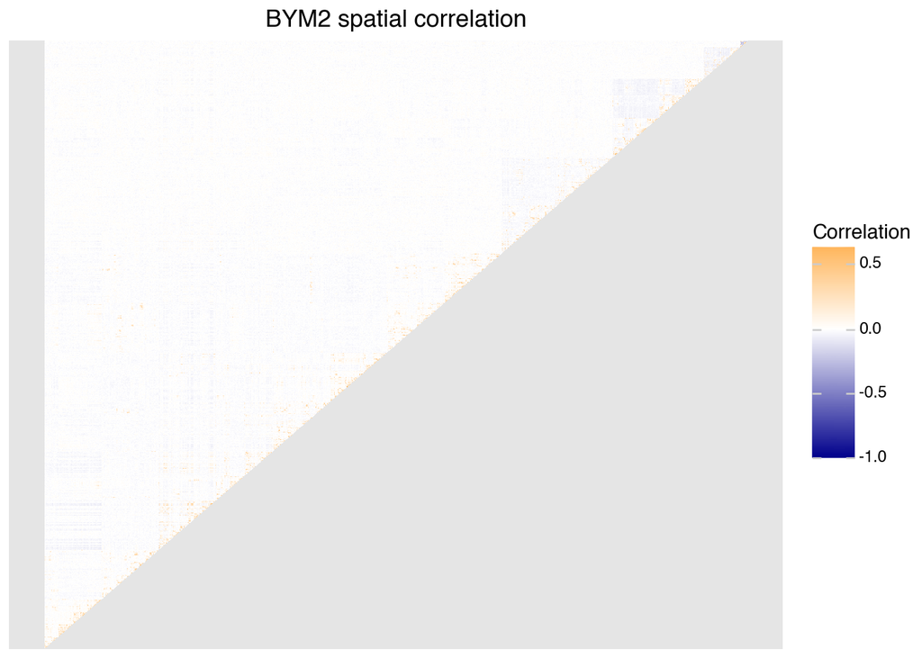

```python
phi_multicomp = bym2_multicomp_fit.stan_variable("phi")
corr_plot = plot_icar_corr_matrix(phi_multicomp, 'BYM2 spatial correlation', (10, 10))
corr_plot
```

**R**

````markdown
```{r}
phi_multicomp <- as_draws_matrix(bym2_multicomp_fit$draws("phi"))
plot_icar_corr_matrix(phi_multicomp, 'BYM2 spatial correlation')
```
````

Plotting the entire correlation matrix puts all covariances on the same scale. Plotting the component-by-component correlations more clearly shows the spatial structure. The first three components correspond to Brooklyn and Queens (minus the Rockaways), Manhattan (minus Roosevelt Island), and the Bronx (minus City Island), respectively.

**Python**

```python
corr_plots = []
start_idx = 1
for i in range(N_components):
    end_idx = component_sizes[i] + start_idx
    phi_slice = phi_multicomp[ : , start_idx : end_idx ]
    corr_plots.append(plot_icar_corr_matrix(phi_slice,
        "Spatial Correlation vector phi_"+str(i)+"\nBYM2 multicomp",
    size=(10,10)))
```

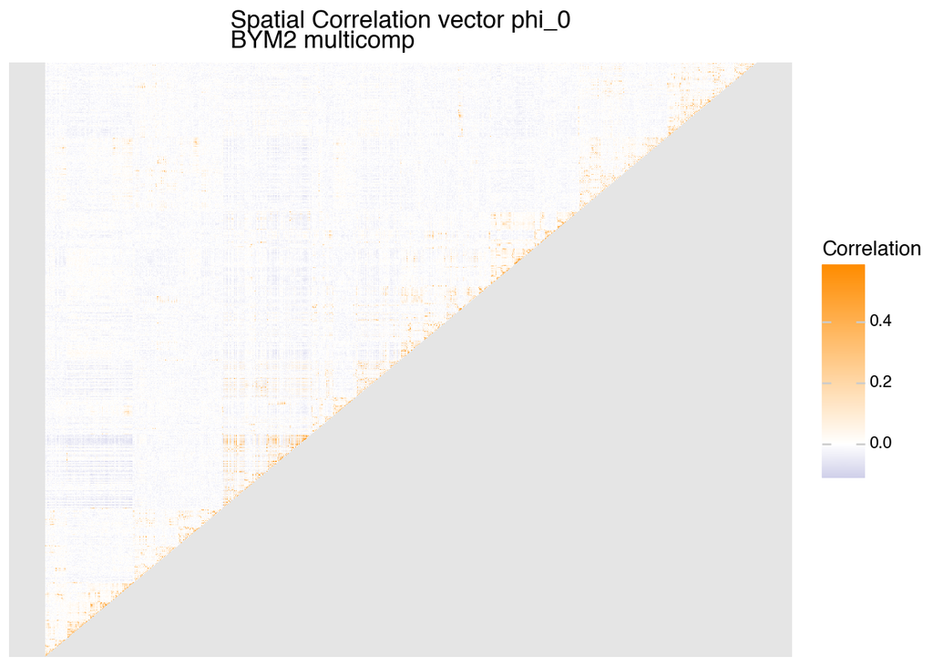

```python
# Brooklyn and Queens (mainland)
corr_plots[0]
```

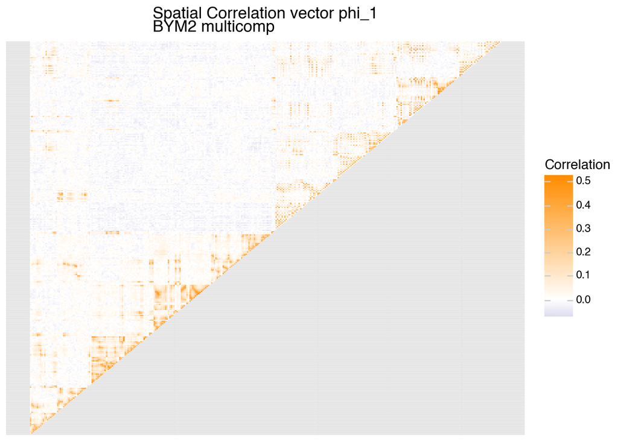

```python
# Manhattan
corr_plots[1]
```

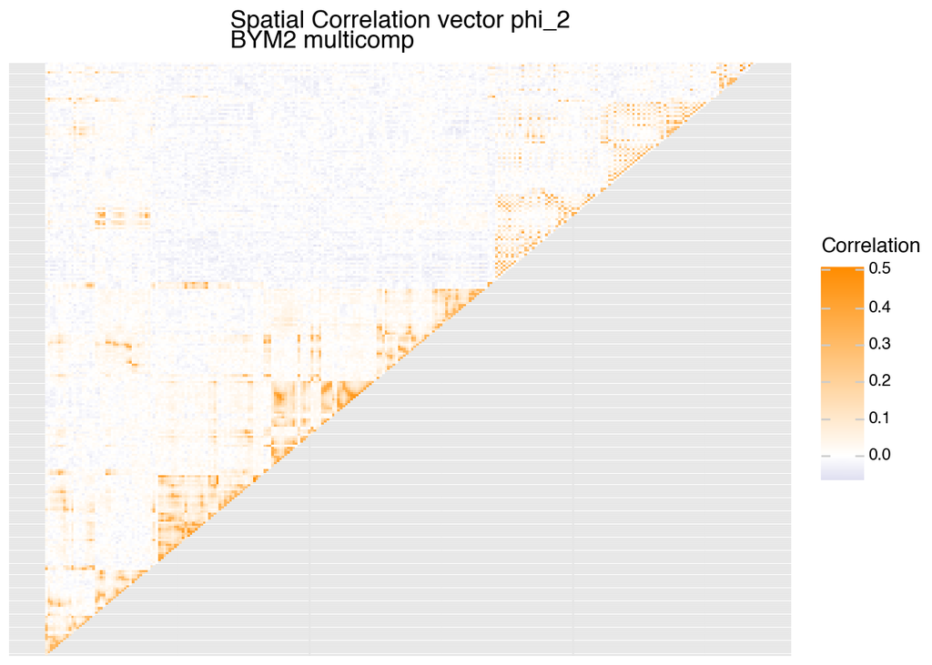

```python
# Bronx
corr_plots[2]
```

**R**

````markdown
```{r}
corr_plots <- list()
start_idx <- 1
for (i in seq_len(N_components)) {
    end_idx <- start_idx + component_sizes[i] - 1
    phi_slice <- phi_multicomp[, start_idx:end_idx]
    corr_plots[[i]] <- plot_icar_corr_matrix(phi_slice,
        paste("Spatial Correlation vector phi_", i, "\nBYM2 multicomp", sep = ""))
    start_idx <- end_idx + 1
}
```
````

````markdown
```{r}
# Brooklyn and Queens (mainland)
corr_plots[1]
```
````

````markdown
```{r}
# Manhattan
corr_plots[2]
```
````

````markdown
```{r}
# Bronx
corr_plots[3]
```
````

### Posterior predictive checks

**Python**

```
PPC BYM2
 y total: 2095, ct y is within y_rep central 50% interval: 2008, pct: 95.8472553699284
```

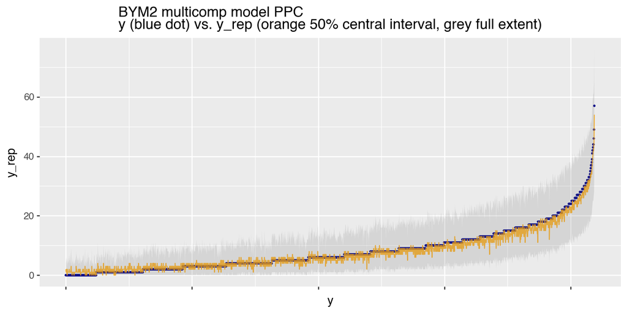

```python
y_rep_multicomp = bym2_multicomp_fit.stan_variable("y_rep")
print("PPC BYM2\n", ppc_central_interval(y_rep_multicomp, bym2_data['y']))

ppc_plot = ppc_y_yrep_overlay(y_rep_multicomp, bym2_data['y'],
                                'BYM2 multicomp model PPC\ny (blue dot) vs. y_rep (orange 50% central interval, grey full extent)')
ppc_plot
```

**R**

````markdown
```{r}
y_rep_multicomp <- as_draws_matrix(bym2_multicomp_fit$draws("y_rep"))
cat("PPC BYM2_multicomp")
ppc_central_interval(y_rep_multicomp, bym2_data$y)

ppc_y_yrep_overlay(y_rep_multicomp, bym2_data$y,
                     'BYM2 multicomp model PPC\ny (blue dot) vs. y_rep (orange 50% central interval, grey full extent)')
```
````

## Model Comparison

### BYM2 fully connected vs. BYM2_multicomp

We can create a fully connected neighbor graph of NYC, as was done in the 2019 study, by making the following edits to the neighbor graph:

- connect Staten Island to Bay Ridge
- connect Breezy Point to the Rockaways
- connect Broad Channel to Queens
- connect Broad Channel to the Rockaways
- connect Roosevelt Island to Queens
- connect Manhattan to Bronx
- connect City Island to Bronx

As the census tract map already connects Manhattan to Brooklyn and Queens according to bridges and tunnels, we keep these connections as well. We have written helper functions to do this as part of the `utils_nyc_map.py` and `utils_nyc_map.R` files.

**Python**

```python
nyc_connected_nbs = connect_nyc(nyc_geodata)
print(f'number of components: {nyc_connected_nbs.n_components}')
print(f'islands? {nyc_connected_nbs.islands}')
print(f'mean number of neighbors per node: {nyc_connected_nbs.mean_neighbors}')
```

```
number of components: 1
islands? []
mean number of neighbors per node: 5.897852028639618
```

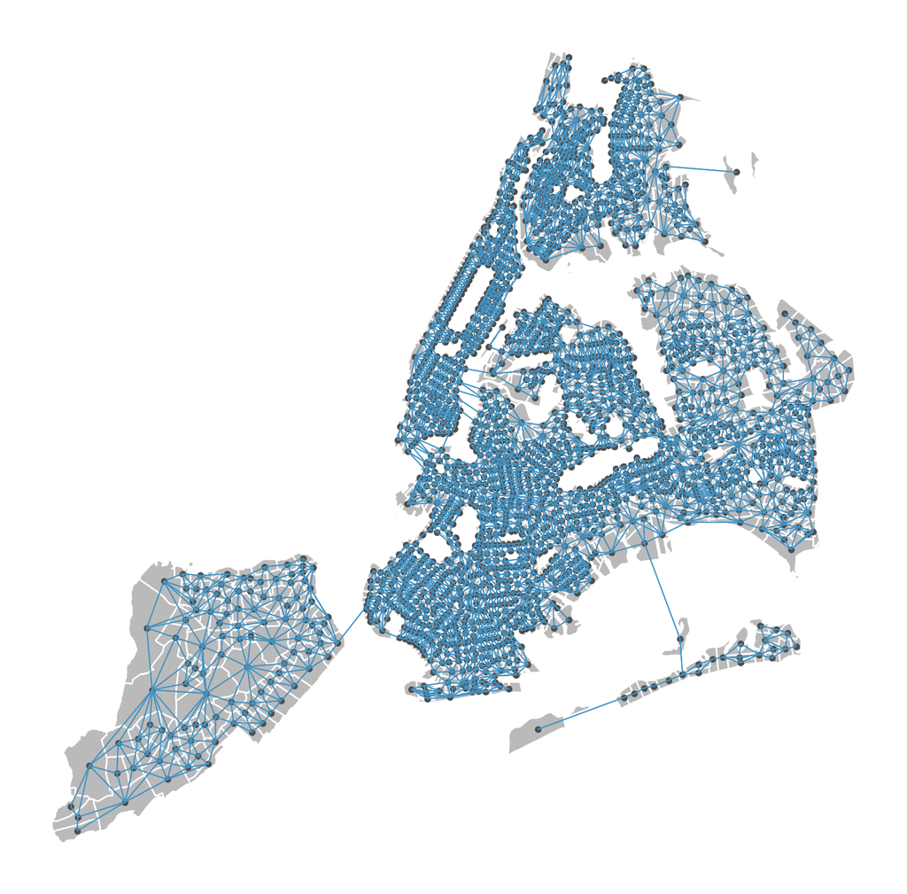

```python
plot_spatial_weights(nyc_connected_nbs, nyc_geodata)
```

**R**

````markdown
```{r}
nyc_connected_nbs = connect_nyc(nyc_geodata)
```
````

Compute the scaling factor `tau` for `nyc_connected_nbs`, along with the list of neighbor pairs.

**Python**

```python
nyc_connected_nbs_adj = nbs_to_adjlist(nyc_connected_nbs)
N_edges = nyc_connected_nbs_adj.shape[1]
tau = get_scaling_factor(nyc_connected_nbs)
print("N_edges:",N_edges,", tau",tau.round(2))
```

```
N_edges: 6178 , tau 1.3
```

**R**

````markdown
```{r}
nyc_connected_nbs_adj = nbs_to_adjlist(nyc_connected_nbs)
N_edges = ncol(nyc_connected_nbs_adj)
tau = get_scaling_factor(nyc_connected_nbs)
cat("N_edges: ",N_edges,", tau ",tau)
```
````

#### Prior predictive checking: is variance of scaled `phi` approx $1$?

Create the input data dict, list for the model `bym2_gamma_ppc.stan`.

**Python**

```python
design_mat = nyc_geodata[["pct_pubtransit", "med_hh_inc", "frag_index", "traffic"]].copy()
design_mat["med_hh_inc"] = np.log(design_mat["med_hh_inc"])
design_mat["traffic"] = np.log(design_mat["traffic"])

bym2_1comp_data = {
    "N": len(nyc_geodata),
    "y": nyc_geodata["count"].astype(int).values,
    "E": nyc_geodata["kid_pop"].astype(int).values,
    "K": 4,
    "xs": design_mat.values,
    "N_edges": N_edges,
    "neighbors": nyc_connected_nbs_adj,
    "tau": tau
}
```

**R**

````markdown
```{r}
design_mat <- as.data.frame(nyc_geodata) %>%
  select(pct_pubtransit, med_hh_inc, traffic, frag_index) %>%
  mutate(med_hh_inc = log(med_hh_inc),
         traffic = log(traffic))

bym2_1comp_data <- list(
  N = nrow(nyc_geodata),
  y = as.integer(nyc_geodata$count),
  E = as.integer(nyc_geodata$kid_pop),
  K = 4,
  xs = design_mat,
  N_edges = ncol(nyc_connected_nbs_adj),
  neighbors = nyc_connected_nbs_adj,
  tau = tau
)
```
````

Fit prior predictive model, check variance of scaled prior `phi` as well as `theta`.

**Python**

```python
bym2_gamma_ppc_mod = CmdStanModel(stan_file = os.path.join('..', 'stan', 'bym2_gamma_ppc.stan'))
bym2_1comp_gamma_ppc_fit = bym2_gamma_ppc_mod.sample(data = bym2_1comp_data)
```

```
09:46:20 - cmdstanpy - INFO - CmdStan start processing
```

```
09:46:41 - cmdstanpy - INFO - CmdStan done processing.
```

```python
phi = bym2_1comp_gamma_ppc_fit.stan_variable('phi')
phi_var_by_region = np.var((np.sqrt(1/tau) * phi), axis=0)
print('mean variance of phi scaled', np.mean(phi_var_by_region))

theta = bym2_1comp_gamma_ppc_fit.stan_variable('theta')
print('mean variance of theta', np.mean(np.var(theta, axis=0)))
```

```
mean variance of phi scaled 1.0016676356492287
mean variance of theta 0.9995915523459598
```

**R**

````markdown
```{r}
bym2_gamma_ppc_mod = cmdstan_model(stan_file=file.path('..', 'stan', 'bym2_gamma_ppc.stan'))
bym2_1comp_gamma_ppc_fit = bym2_gamma_ppc_mod$sample(data=bym2_1comp_data, parallel_chains=cores, refresh=0)
```
````

````markdown
```{r}
phi <- as_draws_matrix(bym2_1comp_gamma_ppc_fit$draws("phi"))
phi_scaled <- sweep(phi, 2, sqrt(1 / taus), "*")
phi_var_by_region <- apply(phi, 2, var)
print(paste("mean variance of phi scaled:", mean(phi_var_by_region)))

theta <- as_draws_matrix(bym2_1comp_gamma_ppc_fit$draws("theta"))
theta_var_by_region <- apply(theta, 2, var)
print(paste("mean variance of theta:", mean(theta_var_by_region)))
```
````

Check the variance of `phi`, unscaled (as in the Leroux model).

**Python**

```python
np.mean(np.var(phi, axis=0))
```

```
1.3071535482665657
```

**R**

````markdown
```{r}
mean(apply(phi, 2, var))
```
````

#### Model fitting

To see the overall effect of creating a single connected component, which can be fit using the BYM2 model, we fit the model on the data, and then compare the model estimates.

**Python**

```python
bym2_mod = CmdStanModel(stan_file = os.path.join('..', 'stan', 'bym2.stan'))
bym2_1comp_fit = bym2_mod.sample(data=bym2_1comp_data, iter_warmup=5000, iter_sampling=2000)

bym2_1comp_summary = bym2_1comp_fit.summary()
bym2_1comp_summary.round(2).loc[
  ['beta_intercept', 'beta0', 'betas[1]', 'betas[2]', 'betas[3]', 'betas[4]', 'sigma', 'rho']]
```

```
09:46:44 - cmdstanpy - INFO - CmdStan start processing
```

```
09:47:57 - cmdstanpy - INFO - CmdStan done processing.
```

|  | Mean | MCSE | StdDev | MAD | 5% | 50% | 95% | ESS_bulk | ESS_tail | R_hat |
| --- | --- | --- | --- | --- | --- | --- | --- | --- | --- | --- |
| beta_intercept | -7.40 | 0.03 | 0.75 | 0.76 | -8.61 | -7.40 | -6.14 | 594.57 | 1275.35 | 1.01 |
| beta0 | -4.47 | 0.00 | 0.02 | 0.02 | -4.50 | -4.47 | -4.44 | 3314.23 | 5352.21 | 1.00 |
| betas[1] | 0.95 | 0.01 | 0.22 | 0.22 | 0.60 | 0.95 | 1.31 | 415.32 | 967.95 | 1.00 |
| betas[2] | 0.16 | 0.00 | 0.06 | 0.06 | 0.06 | 0.16 | 0.26 | 623.90 | 1558.99 | 1.01 |
| betas[3] | 0.08 | 0.00 | 0.01 | 0.01 | 0.06 | 0.08 | 0.10 | 1069.12 | 2878.40 | 1.00 |
| betas[4] | 0.05 | 0.00 | 0.02 | 0.02 | 0.01 | 0.05 | 0.08 | 2546.15 | 4387.53 | 1.00 |
| sigma | 0.93 | 0.00 | 0.05 | 0.05 | 0.86 | 0.93 | 1.01 | 204.55 | 694.72 | 1.02 |
| rho | 0.61 | 0.00 | 0.06 | 0.06 | 0.51 | 0.62 | 0.70 | 189.37 | 508.96 | 1.02 |

**R**

````markdown
```{r}
bym2_mod = cmdstan_model(stan_file=file.path('..', 'stan', 'bym2.stan'))
bym2_1comp_fit = bym2_mod$sample(data=bym2_1comp_data, parallel_chains=cores, iter_warmup=5000, iter_sampling=2000, refresh=0)
bym2_1comp_fit$print(variables = c('beta_intercept', 'beta0', 'betas[1]', 'betas[2]', 'betas[3]', 'betas[4]', 'sigma', 'rho'))
```
````

#### Visualizing ICAR component differences

After fitting the model, we use a series of heatmaps to visualize the differences between estimated parameters and quantities of interest, using function `plot_heatmap`, defined in files `utils_dataviz.py` and `utils_dataviz.R`, respectively.

The input dataset `bym2_1comp_data` is created from `nyc_geodata`, therefore the model outputs follow this ordering. The input dataset `bym2_data` is created from the reordered geodataframe `nyc_gdf`. In order to compare the outputs from `bym2_1comp_fit` and `bym2_multicomp_fit`, we need to reorder the former according to the latter.

**Python**

```python
sort_index = np.searchsorted(
    np.sort(nyc_geodata["ct2010full"].values),
    nyc_gdf["ct2010full"].values
)
```

**R**

````markdown
```{r}
sort_index <- match(nyc_gdf$ct2010full, nyc_geodata$ct2010full)
```
````

In addition, to compare estimates of spatial component vector `phi`, we must pad the BYM2_multicomp one, because it doesn’t include the three singletons in the map (City Island, Broad Channel, and Breezy Point).

**Python**

```python
phi_multicomp = bym2_multicomp_fit.stan_variable('phi')
phi_multicomp_padded = np.concatenate([phi_multicomp, np.zeros((phi_multicomp.shape[0], 3))], axis=1)
```

**R**

````markdown
```{r}
phi_multicomp = as_draws_matrix(bym2_multicomp_fit$draws("phi"))
phi_multicomp_padded = cbind(phi_multicomp, matrix(0, nrow = nrow(phi_multicomp), ncol=3))
```
````

We compute the difference between the per-tract mean estimates and plot the resulting heatmap.

**Python**

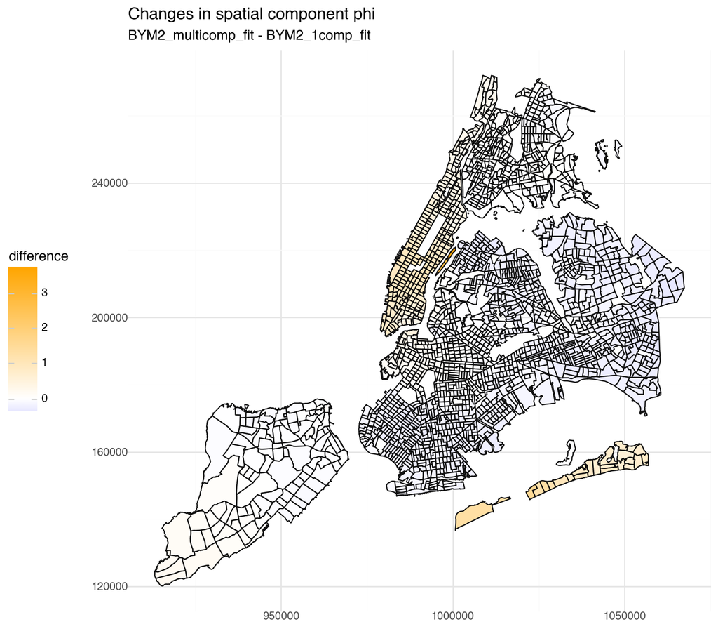

```python
# BYM2 multicomp estimates
phi_multicomp_mean = np.mean(phi_multicomp_padded, axis=0)

# BYM2 1comp estimates
phi_1comp = bym2_1comp_fit.stan_variable('phi')
phi_1comp_sorted = phi_1comp[:, sort_index]
phi_1comp_mean = np.mean(phi_1comp_sorted, axis=0)

# compare via heatmap plot
phi_diff = phi_multicomp_mean - phi_1comp_mean
plot_heatmap(nyc_gdf, phi_diff,
             "Changes in spatial component phi",
             "BYM2_multicomp_fit - BYM2_1comp_fit", "difference", (8, 7))
```

**R**

````markdown
```{r}
# BYM2 multicomp estimates
phi_multicomp_mean = apply(phi_multicomp_padded, 2, mean)

# BYM2 1comp estimates
phi_1comp = as_draws_matrix(bym2_1comp_fit$draws("phi"))
phi_1comp_sorted <- phi_1comp[, sort_index]
phi_1comp_mean = apply(phi_1comp_sorted, 2, mean)

# compare via heatmap plot
phi_diff <- phi_multicomp_mean - phi_1comp_mean
plot_heatmap(nyc_gdf, phi_diff,
             "Changes in spatial component phi",
             "BYM2_multicomp_fit - BYM2_1comp_fit", "difference")
```
````

##### Compare fitted estimates

**Python**

```python
print("BYM2 1comp fit")
bym2_1comp_summary.round(2).loc[
  ['beta_intercept', 'beta0', 'betas[1]', 'betas[2]', 'betas[3]', 'betas[4]', 'sigma', 'rho']]

print("BYM2_multicomp fit")
bym2_multicomp_summary.round(2).loc[
  ['beta_intercept', 'beta0', 'betas[1]', 'betas[2]', 'betas[3]', 'betas[4]', 'sigma', 'rho']]
```

```
BYM2 1comp fit
BYM2_multicomp fit
```

|  | Mean | MCSE | StdDev | MAD | 5% | 50% | 95% | ESS_bulk | ESS_tail | R_hat |
| --- | --- | --- | --- | --- | --- | --- | --- | --- | --- | --- |
| beta_intercept | -5.77 | 0.01 | 0.57 | 0.57 | -6.70 | -5.78 | -4.82 | 1508.50 | 2760.33 | 1.00 |
| beta0 | -4.48 | 0.00 | 0.02 | 0.02 | -4.50 | -4.48 | -4.45 | 3571.08 | 4440.29 | 1.00 |
| betas[1] | 0.82 | 0.00 | 0.16 | 0.16 | 0.56 | 0.82 | 1.09 | 1344.03 | 2727.40 | 1.00 |
| betas[2] | 0.04 | 0.00 | 0.05 | 0.05 | -0.04 | 0.04 | 0.12 | 1353.65 | 2656.53 | 1.00 |
| betas[3] | 0.03 | 0.00 | 0.02 | 0.02 | -0.00 | 0.03 | 0.06 | 2794.78 | 4605.22 | 1.00 |
| betas[4] | 0.04 | 0.00 | 0.01 | 0.01 | 0.02 | 0.04 | 0.05 | 2003.72 | 3604.78 | 1.00 |
| sigma | 0.78 | 0.00 | 0.02 | 0.02 | 0.74 | 0.78 | 0.82 | 540.03 | 1457.11 | 1.01 |
| rho | 0.39 | 0.00 | 0.05 | 0.05 | 0.31 | 0.39 | 0.48 | 356.72 | 725.14 | 1.01 |

**R**

````markdown
```{r}
cat("BYM2 1comp fit")
bym2_1comp_fit$print(variables = c('beta_intercept', 'beta0', 'betas[1]', 'betas[2]', 'betas[3]', 'betas[4]', 'sigma', 'rho'))


cat("BYM2_multicomp fit")
bym2_multicomp_fit$print(variables = c('beta_intercept', 'beta0', 'betas[1]', 'betas[2]', 'betas[3]', 'betas[4]', 'sigma', 'rho'))

```
````

##### Posterior predictive checks

**Python**

```
PPC BYM2
 y total: 2095, ct y is within y_rep central 50% interval: 2004, pct: 95.6563245823389
```

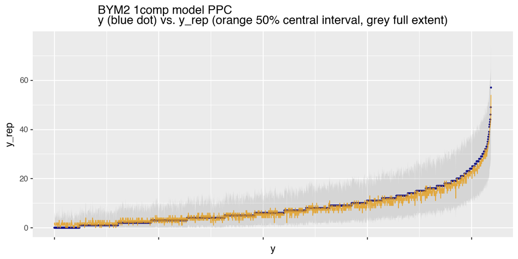

```python
y_rep_1comp = bym2_1comp_fit.stan_variable("y_rep")
print("PPC BYM2\n", ppc_central_interval(y_rep_1comp, bym2_1comp_data['y']))

ppc_plot = ppc_y_yrep_overlay(y_rep_1comp, bym2_1comp_data['y'],
                                'BYM2 1comp model PPC\ny (blue dot) vs. y_rep (orange 50% central interval, grey full extent)')
ppc_plot
```

```
PPC BYM2
 y total: 2095, ct y is within y_rep central 50% interval: 2008, pct: 95.8472553699284
```

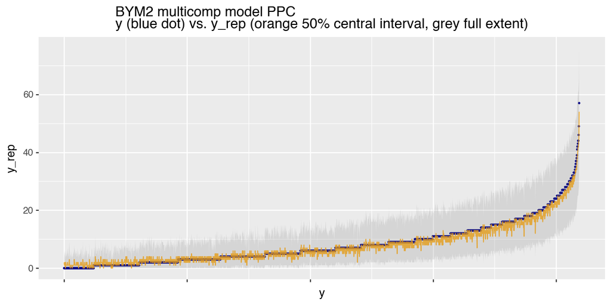

```python
y_rep_multicomp = bym2_multicomp_fit.stan_variable("y_rep")
print("PPC BYM2\n", ppc_central_interval(y_rep_multicomp, bym2_data['y']))

ppc_plot = ppc_y_yrep_overlay(y_rep_multicomp, bym2_data['y'],
                                'BYM2 multicomp model PPC\ny (blue dot) vs. y_rep (orange 50% central interval, grey full extent)')
ppc_plot
```

**R**

````markdown
```{r}
y_rep_1comp <- as_draws_matrix(bym2_1comp_fit$draws("y_rep"))
cat("PPC BYM2_1comp")
ppc_central_interval(y_rep_1comp, bym2_1comp_data$y)

ppc_y_yrep_overlay(y_rep_1comp, bym2_1comp_data$y,
                     'BYM2 1comp model PPC\ny (blue dot) vs. y_rep (orange 50% central interval, grey full extent)')
```
````

````markdown
```{r}
y_rep_multicomp <- as_draws_matrix(bym2_multicomp_fit$draws("y_rep"))
cat("PPC BYM2_multicomp")
ppc_central_interval(y_rep_multicomp, bym2_data$y)

ppc_y_yrep_overlay(y_rep_multicomp, bym2_data$y,
                     'BYM2_multicomp model PPC\ny (blue dot) vs. y_rep (orange 50% central interval, grey full extent)')
```
````

#### Visualizing posterior predictive differences on the map

**Python**

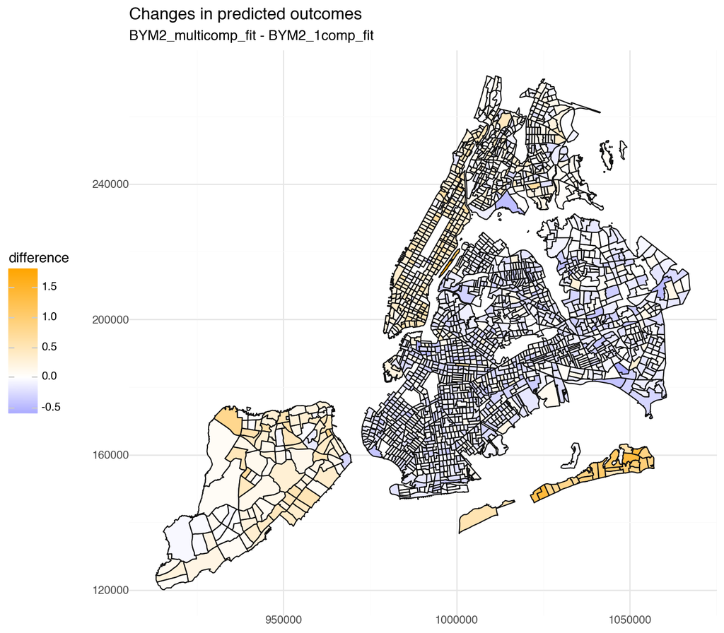

```python
y_rep_multicomp_mean = np.mean(y_rep_multicomp, axis=0)

y_rep_1comp_sorted = y_rep_1comp[:, sort_index]
y_rep_1comp_mean = np.mean(y_rep_1comp_sorted, axis=0)

y_rep_diff = y_rep_multicomp_mean - y_rep_1comp_mean
plot_heatmap(nyc_gdf, y_rep_diff,
             "Changes in predicted outcomes",
             "BYM2_multicomp_fit - BYM2_1comp_fit", "difference", (8, 7))
```

**R**

````markdown
```{r}
y_rep_multicomp = as_draws_matrix(bym2_multicomp_fit$draws("y_rep"))
y_rep_multicomp_mean <- apply(y_rep_multicomp, 2, mean)

y_rep_1comp_sorted <- y_rep_1comp[, sort_index]
y_rep_1comp_mean <- apply(y_rep_1comp_sorted, 2, mean)

y_rep_diff = y_rep_multicomp_mean - y_rep_1comp_mean
plot_heatmap(nyc_gdf, y_rep_diff,
             "Changes in predicted outcomes",
             "BYM2_multicomp_fit - BYM2_1comp_fit", "difference")
```
````

## Discussion

The BYM2_multicomp model requires a few more kinds of input data to identify the number and size of the disconnected components and singletons. It also requires that the data be organized by component, in order to allow for efficient computation. This, in turn, increases the number of steps required to assemble the data inputs.

Assembling the spatial effects vector `phi` from a series of ICAR components, each of which has a sum-to-zero constraint for identifiability, requires a by-hand implementation of the constraining transform for the sum-to-zero vector; this increases the size and complexity of the model.

However, the alternative is to edit the neighbor graph so that all components are connected. This is problematic for the following reasons:

- Editing neighbor graphs is tedious and error-prone.
- It imposes artificial spatial correlations in the model.
- Adding edges boosts the geometric mean of the row sums, thus affecting the scaling factor, which results in a falsely inflated estimate of the parameter `rho`, the fraction of spatial variance.

The BYM2_multicomp model provides a principled alternative.